# Data analysis report for Xiangyu Bu

En Fu

3/11/2021

```
## here() starts at C:/Users/efu19/OneDrive/Documents/AcademicResearch/HLMpaper/HLMstudentProjects/xiangyu/analyses3_12
```

This report present data analysis results for the relationships among smartphone use motive, online social support, and experience of positive and negative emotions after smartphone use in adolescents.

**Part1**  
#Check for covariates and multicollinearity

##check for multicollinearity among the IVs

```
## Correlations of the variables
##
##             posbi     online        Age
## posbi  1.00000000 0.02757649 0.02171618
## online 0.02757649 1.00000000 0.16122704
## Age    0.02171618 0.16122704 1.00000000
##
##
## Variance inflation factors
##
##            GVIF
## posbi  1.001068
## online 1.027300
## Age    1.027003
```

```
## Correlations of the variables
##
##             negbi    online        Age
## negbi  1.00000000 0.1524907 0.02711021
## online 0.15249075 1.0000000 0.16114761
## Age    0.02711021 0.1611476 1.00000000
##
##
## Variance inflation factors
##
##            GVIF
## negbi  1.023814
## online 1.050337
## Age    1.026668
```

##check for covariates

###Association between demographic variables and emotion experiences

Frequency of male and female students reporting presence and absence of positive and negative emotions after smartphone use

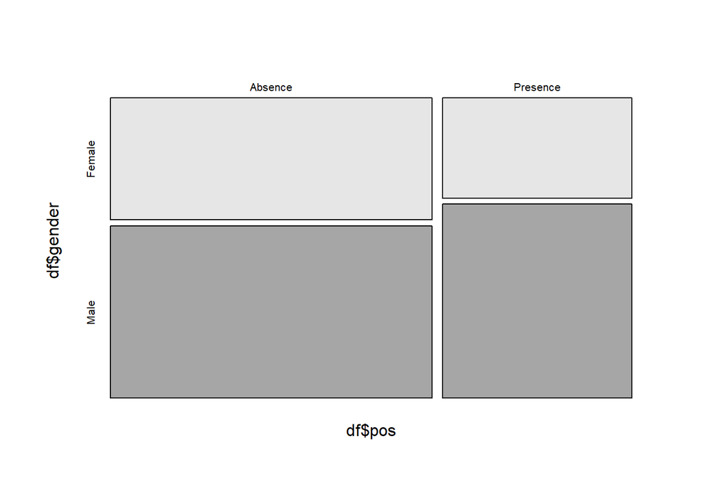

```
##    Cell Contents
## |-------------------------|
## |                   Count |
## |-------------------------|
##
## =======================================
##              df$pos
## df$gender    Absence   Presence   Total
## ---------------------------------------
## Female           424        205     629
## ---------------------------------------
## Male             599        397     996
## ---------------------------------------
## Total           1023        602    1625
## =======================================
```

```
##
##  Pearson's Chi-squared test with Yates' continuity correction
##
## data:  df$gender and df$pos
## X-squared = 8.4233, df = 1, p-value = 0.003704
```

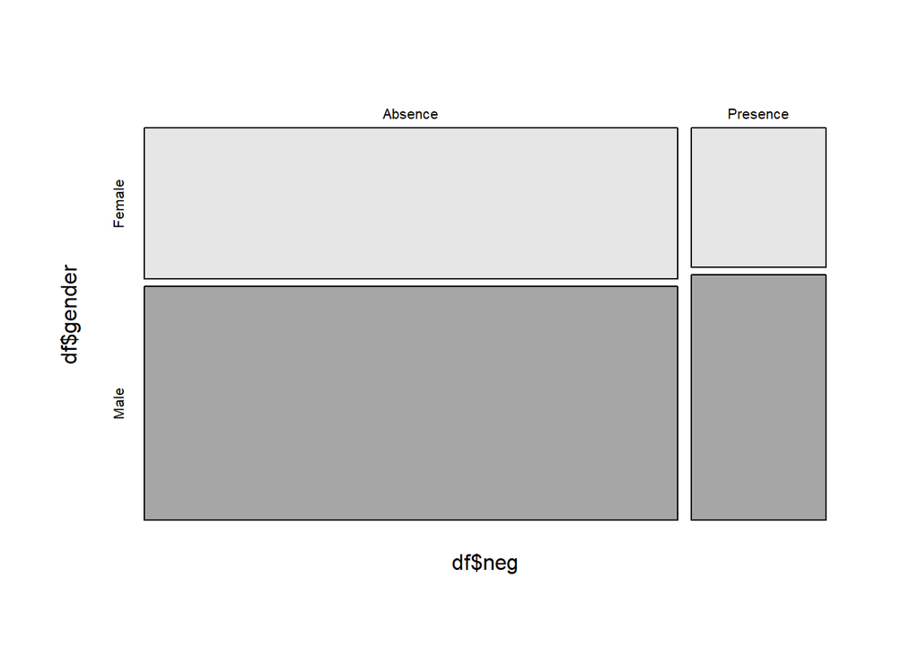

```
##    Cell Contents
## |-------------------------|
## |                   Count |
## |-------------------------|
##
## =======================================
##              df$neg
## df$gender    Absence   Presence   Total
## ---------------------------------------
## Female           508        118     626
## ---------------------------------------
## Male             788        208     996
## ---------------------------------------
## Total           1296        326    1622
## =======================================
```

```
##
##  Pearson's Chi-squared test with Yates' continuity correction
##
## data:  df$gender and df$neg
## X-squared = 0.86741, df = 1, p-value = 0.3517
```

Frequency of 7th and 8th grade students reporting presence and absence of positive and negative emotions after smartphone use

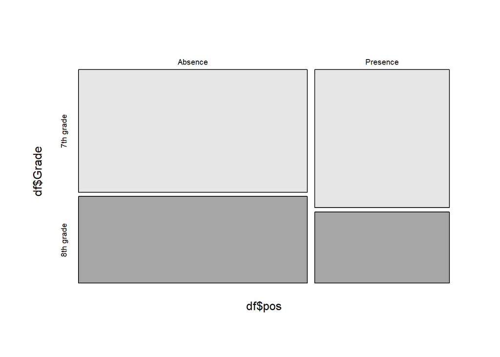

```
##    Cell Contents
## |-------------------------|
## |                   Count |
## |-------------------------|
##
## =======================================
##              df$pos
## df$Grade     Absence   Presence   Total
## ---------------------------------------
## 7th grade        599        397     996
## ---------------------------------------
## 8th grade        424        205     629
## ---------------------------------------
## Total           1023        602    1625
## =======================================
```

```
##
##  Pearson's Chi-squared test with Yates' continuity correction
##
## data:  df$Grade and df$pos
## X-squared = 8.4233, df = 1, p-value = 0.003704
```

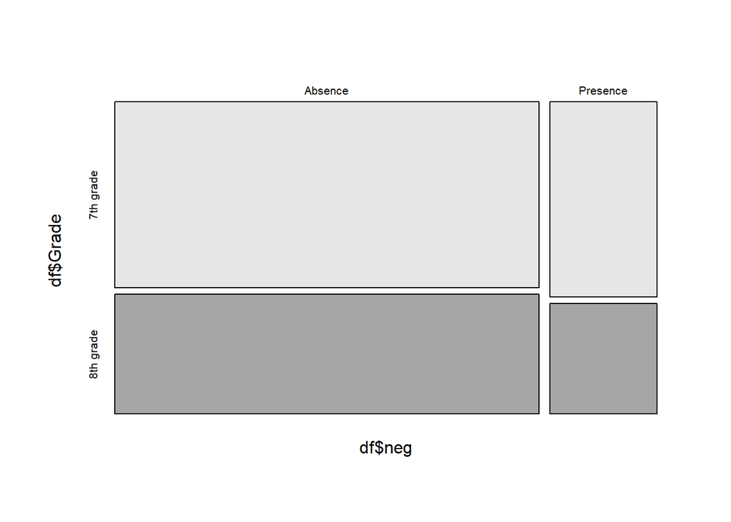

```
##    Cell Contents
## |-------------------------|
## |                   Count |
## |-------------------------|
##
## =======================================
##              df$neg
## df$Grade     Absence   Presence   Total
## ---------------------------------------
## 7th grade        788        208     996
## ---------------------------------------
## 8th grade        508        118     626
## ---------------------------------------
## Total           1296        326    1622
## =======================================
```

```
##
##  Pearson's Chi-squared test with Yates' continuity correction
##
## data:  df$Grade and df$neg
## X-squared = 0.86741, df = 1, p-value = 0.3517
```

Frequency of Shenhu, nonShenhu, and students who didn’t know their Hukou status reporting presence and absence of positive and negative emotions after smartphone use

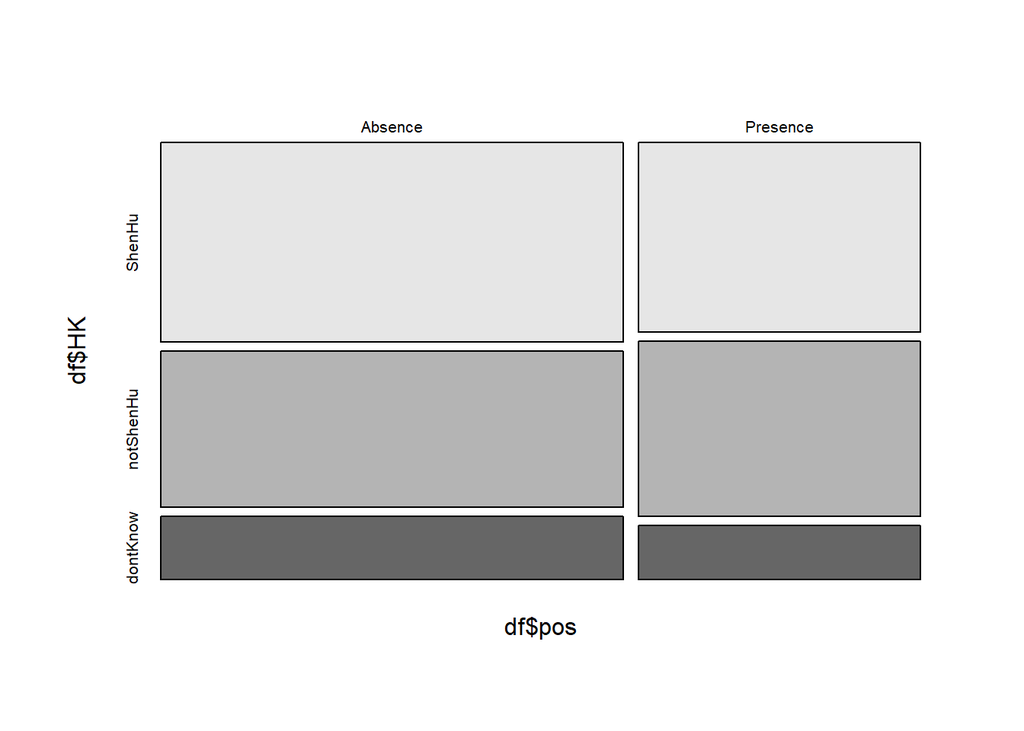

```
##    Cell Contents
## |-------------------------|
## |                   Count |
## |-------------------------|
##
## =======================================
##              df$pos
## df$HK        Absence   Presence   Total
## ---------------------------------------
## ShenHu           404        234     638
## ---------------------------------------
## notShenHu        317        217     534
## ---------------------------------------
## dontKnow         129         67     196
## ---------------------------------------
## Total            850        518    1368
## =======================================
```

```
##
##  Pearson's Chi-squared test
##
## data:  df$HK and df$pos
## X-squared = 3.2553, df = 2, p-value = 0.1964
```

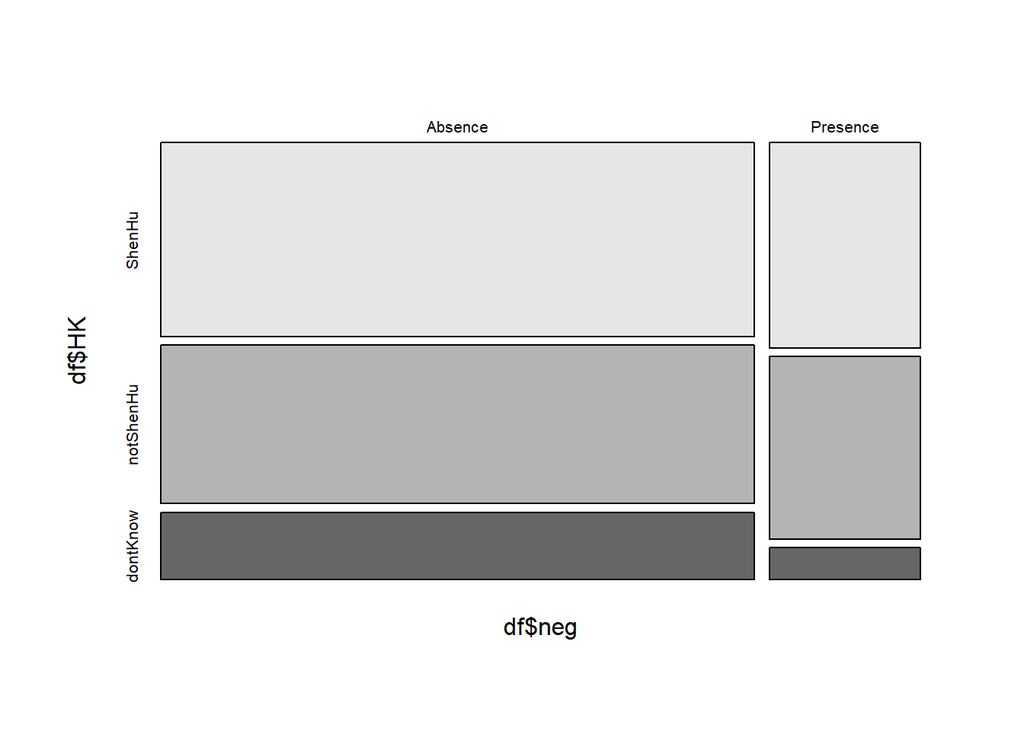

```
##    Cell Contents
## |-------------------------|
## |                   Count |
## |-------------------------|
##
## =======================================
##              df$neg
## df$HK        Absence   Presence   Total
## ---------------------------------------
## ShenHu           503        135     638
## ---------------------------------------
## notShenHu        411        120     531
## ---------------------------------------
## dontKnow         175         21     196
## ---------------------------------------
## Total           1089        276    1365
## =======================================
```

```
##
##  Pearson's Chi-squared test
##
## data:  df$HK and df$neg
## X-squared = 13.191, df = 2, p-value = 0.001367
```

Distribution of the presence of positive and negative emotions after smartphone use across different age groups

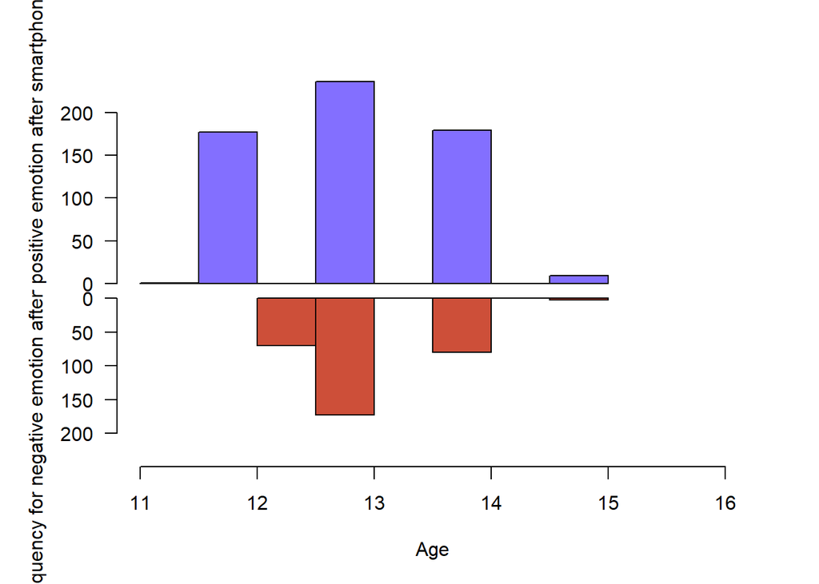

Age difference in those who experienced positive emotion after smartphone use versus those who didn’t

```
##
##  Welch Two Sample t-test
##
## data:  positive_1 and positive_0
## t = 0.87782, df = 1272.2, p-value = 0.3802
## alternative hypothesis: true difference in means is not equal to 0
## 95 percent confidence interval:
##  -0.04537316  0.11885907
## sample estimates:
## mean of x mean of y
##  13.02990  12.99316
```

```
## # A tibble: 3 x 4
##   pos      count `mean(Age)`    sd
##   <chr>    <int> <chr>       <dbl>
## 1 Absence   1023 12.99       0.821
## 2 Presence   602 13.03       0.811
## 3 <NA>         4 12.75       0.5
```

Age difference in those who experienced negative emotion after smartphone use versus those who didn’t

```
##
##  Welch Two Sample t-test
##
## data:  negative_1 and negative_0
## t = 1.2145, df = 582.36, p-value = 0.2251
## alternative hypothesis: true difference in means is not equal to 0
## 95 percent confidence interval:
##  -0.03410068  0.14460587
## sample estimates:
## mean of x mean of y
##  13.04908  12.99383
```

```
## # A tibble: 3 x 4
##   neg      count `mean(Age)`    sd
##   <chr>    <int> <chr>       <dbl>
## 1 Absence   1296 12.99       0.843
## 2 Presence   326 13.05       0.704
## 3 <NA>         7 13.29       0.756
```

**Part2**  
#Sample Characteristics

##Demographic characteristics and phone use behaviors of the sample

```
##   Age Freq
## 1  11   10
## 2  12  464
## 3  13  702
## 4  14  415
## 5  15   35
## 6  16    3
```

```
##   Gender Freq
## 1 Female  629
## 2   Male 1000
```

```
##       Grade Freq
## 1 7th grade 1000
## 2 8th grade  629
```

```
##       HuKou Freq
## 1    ShenHu  641
## 2 notShenHu  534
## 3  dontKnow  196
```

```
##    Age at first phone use Freq
## 1                       3   46
## 2                       4   21
## 3                       5   11
## 4                       6   44
## 5                       7   97
## 6                     7.5    9
## 7                       8  115
## 8                       9  238
## 9                   9.826   82
## 10                     10  378
## 11                     11  183
## 12                     12  229
## 13                     13  145
## 14                     14   26
## 15                     15    5
```

```
##    Hours of using phone on weekdays Freq
## 1                                 0   33
## 2                              0.05   11
## 3                               0.2   16
## 4                       0.333333333    6
## 5                               0.4   14
## 6                               0.5  135
## 7                               0.6   13
## 8                                 1  488
## 9                               1.5   29
## 10                                2  243
## 11                           2.3806   68
## 12                                3  173
## 13                                4  119
## 14                              4.5   15
## 15                                5  167
## 16                              5.5    2
## 17                                6   28
## 18                                7   15
## 19                               10   26
## 20                             14.4   15
## 21                               20   13
```

```
##    Hours of using phone on weekends Freq
## 1                                 0   24
## 2                              0.25   11
## 3                               0.5   46
## 4                                 1  160
## 5                               1.5   24
## 6                                 2  335
## 7                               2.5   18
## 8                                 3  226
## 9                               3.5   20
## 10                                4  161
## 11                           4.1496   97
## 12                              4.5    2
## 13                                5  166
## 14                                6   42
## 15                                7   23
## 16                                8   14
## 17                              8.5   15
## 18                                9   53
## 19                               10  103
## 20                               12   15
## 21                               14   14
## 22                               15   15
## 23                               16   30
## 24                               35   15
```

```
##    Hours of study on weekdays Freq
## 1                           0   14
## 2                           1   30
## 3                         1.5   25
## 4                           2  136
## 5                           3  259
## 6                         3.5   12
## 7                           4   97
## 8                           5   57
## 9                           6   57
## 10                          7   27
## 11                        7.5    2
## 12                          8  152
## 13                          9   66
## 14                      9.547  100
```

[output cut: 17 more lines]

```
##    Hours of study on weekends Freq
## 1                         0.7   14
## 2                           1  117
## 3                           2  138
## 4                         2.5    2
## 5                           3  142
## 6                           4  227
## 7                           5  222
## 8                           6  172
## 9                         6.5   11
## 10                      6.978  105
## 11                          7   15
## 12                          8  106
## 13                          9   49
## 14                         10   82
## 15                         11   28
## 16                         12   53
## 17                       12.5   14
## 18                         13   18
## 19                         14   12
## 20                         15   11
## 21                         18   12
## 22                         20   13
## 23                         23   11
## 24                         24   27
## 25                         30   13
## 26                         50   15
```

Comparing hours of study and smartphone use on weekdays and weekends:

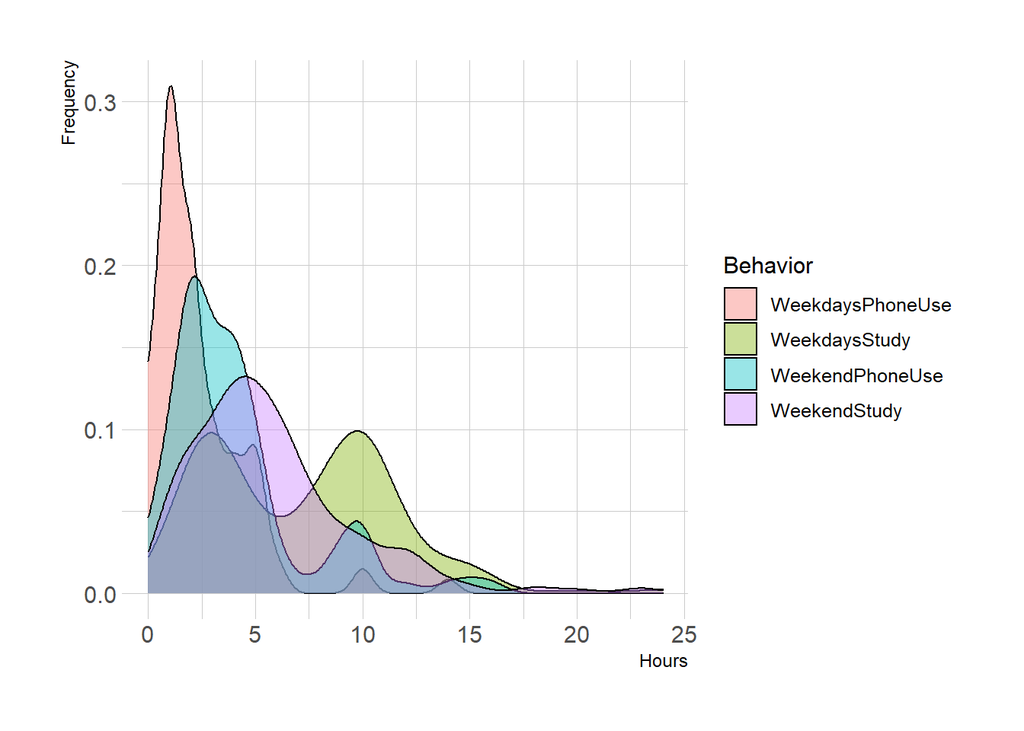

Comparing age at survey and age at first smartphone use

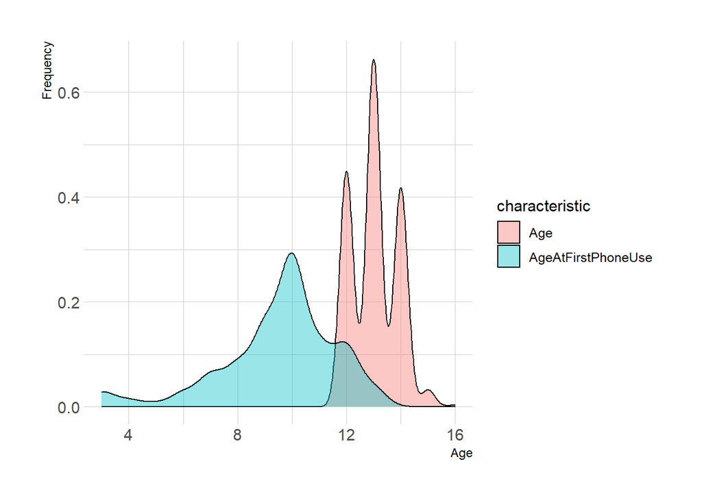

##Emotion experience after smartphone use

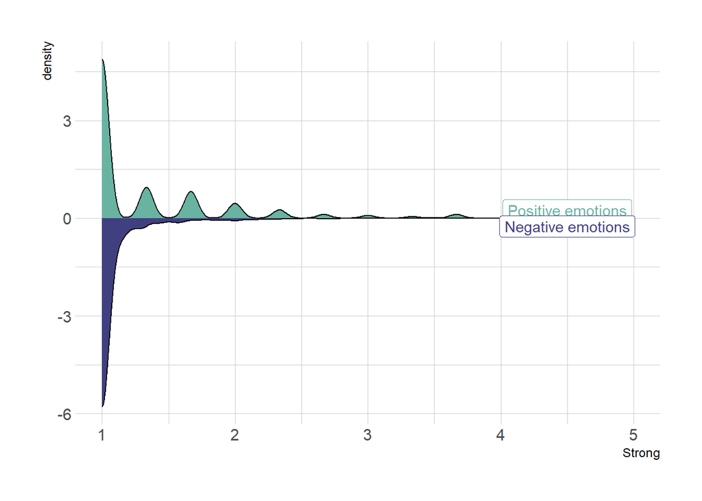

Since majority of the participants responded “none” on both positive and negative emotion experience after smartphone use, we recoded their emotion experience so that both positive and negative emotions are binary variables: absence or 0 if the participant chose “none”, presence or 1 for all other responses.

**Part3**  
#Statistical analyses

##Descriptive statistics

Gender disparity on online social support:

```
##
##  Welch Two Sample t-test
##
## data:  gender_1 and gender_0
## t = -11.378, df = 1590.4, p-value < 2.2e-16
## alternative hypothesis: true difference in means is not equal to 0
## 95 percent confidence interval:
##  -0.5464466 -0.3857430
## sample estimates:
## mean of x mean of y
##  2.954053  3.420147
```

```
## # A tibble: 2 x 4
##   gender count `mean(online)`    sd
##   <chr>  <int> <chr>          <dbl>
## 1 Female   629 3.42           0.697
## 2 Male    1000 2.95           0.952
```

Gender disparity on age

```
##
##  Welch Two Sample t-test
##
## data:  gender_1 and gender_0
## t = 7.114, df = 1399, p-value = 1.794e-12
## alternative hypothesis: true difference in means is not equal to 0
## 95 percent confidence interval:
##  0.2079414 0.3662812
## sample estimates:
## mean of x mean of y
##  13.11700  12.82989
```

```
## # A tibble: 2 x 4
##   gender count `mean(Age)`    sd
##   <chr>  <int> <chr>       <dbl>
## 1 Female   629 12.83       0.773
## 2 Male    1000 13.12       0.825
```

Association between online social support and smartphone use motive

```
##               Df Sum Sq Mean Sq F value   Pr(>F)
## motivef        5   18.4   3.670   4.669 0.000309 ***
## Residuals   1623 1276.0   0.786
## ---
## Signif. codes:  0 '***' 0.001 '**' 0.01 '*' 0.05 '.' 0.1 ' ' 1
```

```
## # A tibble: 6 x 4
##   motivef               count `mean(online)`    sd
##   <fct>                 <int> <chr>          <dbl>
## 1 subconscious            163 3.35           0.894
## 2 bored                   471 3.08           0.932
## 3 study                   843 3.09           0.875
## 4 emergency                60 3.07           0.712
## 5 not in learning state    66 3.47           0.729
## 6 bad mood                 26 3.27           1.08
```

Association between age and smartphone use motive

```
##               Df Sum Sq Mean Sq F value Pr(>F)
## motivef        5    9.8  1.9530   2.945 0.0118 *
## Residuals   1623 1076.2  0.6631
## ---
## Signif. codes:  0 '***' 0.001 '**' 0.01 '*' 0.05 '.' 0.1 ' ' 1
```

```
## # A tibble: 6 x 4
##   motivef               count `mean(Age)`    sd
##   <fct>                 <int> <chr>       <dbl>
## 1 subconscious            163 12.95       0.837
## 2 bored                   471 13.00       0.885
## 3 study                   843 12.98       0.774
## 4 emergency                60 13.13       0.833
## 5 not in learning state    66 13.27       0.669
## 6 bad mood                 26 13.35       0.892
```

Association between online social support and HuKou

```
##               Df Sum Sq Mean Sq F value   Pr(>F)
## HK             2   23.6  11.812   13.96 9.95e-07 ***
## Residuals   1368 1157.4   0.846
## ---
## Signif. codes:  0 '***' 0.001 '**' 0.01 '*' 0.05 '.' 0.1 ' ' 1
## 258 observations deleted due to missingness
```

```
## # A tibble: 4 x 4
##   HK        count `mean(online)`    sd
##   <fct>     <int> <chr>          <dbl>
## 1 ShenHu      641 2.97           0.942
## 2 notShenHu   534 3.20           0.960
## 3 dontKnow    196 3.30           0.708
## 4 <NA>        258 3.27           0.647
```

Association between age and HuKou

```
##               Df Sum Sq Mean Sq F value Pr(>F)
## HK             2   59.1  29.546   50.59 <2e-16 ***
## Residuals   1368  799.0   0.584
## ---
## Signif. codes:  0 '***' 0.001 '**' 0.01 '*' 0.05 '.' 0.1 ' ' 1
## 258 observations deleted due to missingness
```

```
## # A tibble: 4 x 4
##   HK        count `mean(Age)`    sd
##   <fct>     <int> <chr>       <dbl>
## 1 ShenHu      641 12.81       0.731
## 2 notShenHu   534 13.13       0.842
## 3 dontKnow    196 12.54       0.635
## 4 <NA>        258 13.59       0.690
```

Association between grade and online social support

```
##
##  Welch Two Sample t-test
##
## data:  grade_1 and grade_0
## t = -11.378, df = 1590.4, p-value < 2.2e-16
## alternative hypothesis: true difference in means is not equal to 0
## 95 percent confidence interval:
##  -0.5464466 -0.3857430
## sample estimates:
## mean of x mean of y
##  2.954053  3.420147
```

```
## # A tibble: 2 x 4
##   Grade     count `mean(online)`    sd
##   <chr>     <int> <chr>          <dbl>
## 1 7th grade  1000 2.95           0.952
## 2 8th grade   629 3.42           0.697
```

###Graph the gender disparity on smartphone use motivation, age, and online social support

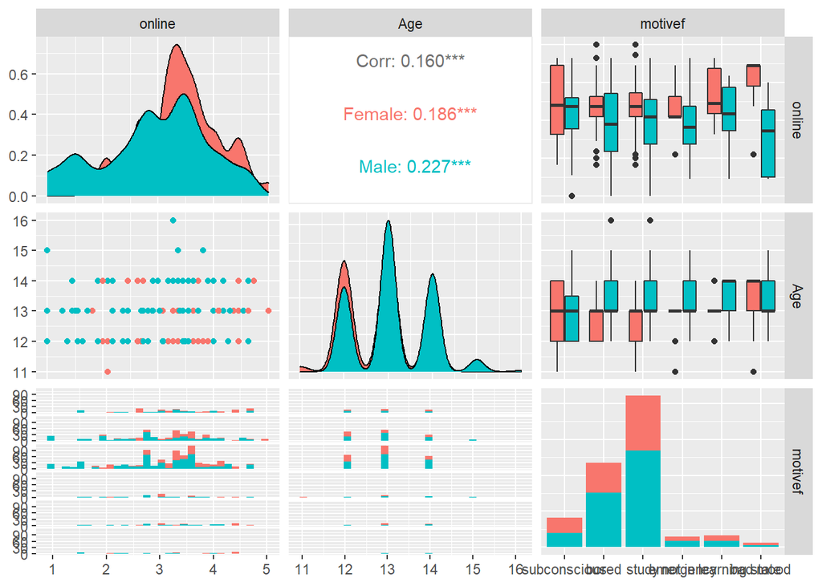

##Inferential statistics

```
## Generalized linear mixed model fit by maximum likelihood (Adaptive
##   Gauss-Hermite Quadrature, nAGQ = 0) [glmerMod]
##  Family: binomial  ( logit )
## Formula: posbi ~ (1 | ID)
##    Data: set
## Control: glmerControl(optimizer = "bobyqa")
##
##      AIC      BIC   logLik deviance df.resid
##   1627.9   1638.7   -812.0   1623.9     1623
##
## Scaled residuals:
##     Min      1Q  Median      3Q     Max
## -2.9296 -0.4937 -0.2761  0.3929  3.1638
##
## Random effects:
##  Groups Name        Variance Std.Dev.
##  ID     (Intercept) 4.315    2.077
## Number of obs: 1625, groups:  ID, 142
##
## Fixed effects:
##             Estimate Std. Error z value Pr(>|z|)
## (Intercept)  -0.7397     0.1916   -3.86 0.000114 ***
## ---
## Signif. codes:  0 '***' 0.001 '**' 0.01 '*' 0.05 '.' 0.1 ' ' 1
```

```
## (Intercept)
##   0.4772495
```

Model1: add covariates and level1 IV

```
## Generalized linear mixed model fit by maximum likelihood (Adaptive
##   Gauss-Hermite Quadrature, nAGQ = 0) [glmerMod]
##  Family: binomial  ( logit )
## Formula: posbi ~ CAge + gender + motivef + (1 | ID)
##    Data: set
## Control: glmerControl(optimizer = "bobyqa")
##
##      AIC      BIC   logLik deviance df.resid
##   1614.4   1662.9   -798.2   1596.4     1616
##
## Scaled residuals:
##     Min      1Q  Median      3Q     Max
## -2.9155 -0.4637 -0.2572  0.3742  3.3818
##
## Random effects:
##  Groups Name        Variance Std.Dev.
##  ID     (Intercept) 4.284    2.07
## Number of obs: 1625, groups:  ID, 142
##
## Fixed effects:
##                              Estimate Std. Error z value Pr(>|z|)
## (Intercept)                  -0.32275    0.39317  -0.821  0.41170
## CAge                         -0.01764    0.23006  -0.077  0.93887
## genderMale                    0.53732    0.40218   1.336  0.18154
## motivefbored                 -0.35938    0.30292  -1.186  0.23547
## motivefstudy                 -1.12212    0.29467  -3.808  0.00014 ***
## motivefemergency             -1.09214    0.49675  -2.199  0.02791 *
## motivefnot in learning state -0.43117    0.42996  -1.003  0.31595
## motivefbad mood              -0.97108    0.62070  -1.564  0.11770
## ---
## Signif. codes:  0 '***' 0.001 '**' 0.01 '*' 0.05 '.' 0.1 ' ' 1
##
## Correlation of Fixed Effects:
##             (Intr) CAge   gndrMl mtvfbr mtvfst mtvfmr mtvils
## CAge         0.106
## genderMale  -0.607 -0.188
## motivefbord -0.540  0.004 -0.040
## motivefstdy -0.577  0.008 -0.039  0.752
## motvfmrgncy -0.332 -0.004 -0.017  0.452  0.475
## mtvfntinlrs -0.352 -0.021  0.000  0.451  0.489  0.314
## motivefbdmd -0.225 -0.014 -0.002  0.296  0.313  0.193  0.190
```

```
##                  (Intercept)                         CAge
##                    0.7241541                    0.9825131
##                   genderMale                 motivefbored
##                    1.7114195                    0.6981062
##                 motivefstudy             motivefemergency
##                    0.3255900                    0.3354978
## motivefnot in learning state              motivefbad mood
##                    0.6497485                    0.3786731
```

Model2: add level2 IV

```
## Generalized linear mixed model fit by maximum likelihood (Adaptive
##   Gauss-Hermite Quadrature, nAGQ = 0) [glmerMod]
##  Family: binomial  ( logit )
## Formula: posbi ~ CAge + gender + motivef + Conline + (1 | ID)
##    Data: set
## Control: glmerControl(optimizer = "bobyqa")
##
##      AIC      BIC   logLik deviance df.resid
##   1615.6   1669.6   -797.8   1595.6     1615
##
## Scaled residuals:
##     Min      1Q  Median      3Q     Max
## -2.8810 -0.4663 -0.2534  0.3724  3.4126
##
## Random effects:
##  Groups Name        Variance Std.Dev.
##  ID     (Intercept) 4.278    2.068
## Number of obs: 1625, groups:  ID, 142
##
## Fixed effects:
##                              Estimate Std. Error z value Pr(>|z|)
## (Intercept)                  -0.37394    0.39901  -0.937 0.348669
## CAge                         -0.04894    0.23388  -0.209 0.834235
## genderMale                    0.61388    0.41491   1.480 0.138997
## motivefbored                 -0.35309    0.30310  -1.165 0.244050
## motivefstudy                 -1.11565    0.29477  -3.785 0.000154 ***
## motivefemergency             -1.08408    0.49665  -2.183 0.029053 *
## motivefnot in learning state -0.43027    0.43008  -1.000 0.317101
## motivefbad mood              -0.96548    0.61937  -1.559 0.119042
## Conline                       0.16691    0.22408   0.745 0.456345
## ---
## Signif. codes:  0 '***' 0.001 '**' 0.01 '*' 0.05 '.' 0.1 ' ' 1
##
## Correlation of Fixed Effects:
##             (Intr) CAge   gndrMl mtvfbr mtvfst mtvfmr mtvils mtvfbm
## CAge         0.134
## genderMale  -0.622 -0.224
## motivefbord -0.537 -0.001 -0.031
## motivefstdy -0.574  0.002 -0.030  0.753
## motvfmrgncy -0.331 -0.008 -0.011  0.453  0.475
## mtvfntinlrs -0.347 -0.021  0.001  0.451  0.489  0.314
## motivefbdmd -0.224 -0.016  0.001  0.297  0.314  0.193  0.190
## Conline     -0.173 -0.180  0.248  0.028  0.029  0.022  0.002  0.012
```

```
##                  (Intercept)                         CAge
##                    0.6880191                    0.9522345
##                   genderMale                 motivefbored
##                    1.8475866                    0.7025156
##                 motivefstudy             motivefemergency
##                    0.3277015                    0.3382133
## motivefnot in learning state              motivefbad mood
##                    0.6503337                    0.3808000
##                      Conline
##                    1.1816484
```

Model3: add cross-level interaction term

```
## Generalized linear mixed model fit by maximum likelihood (Adaptive
##   Gauss-Hermite Quadrature, nAGQ = 0) [glmerMod]
##  Family: binomial  ( logit )
## Formula: posbi ~ CAge + gender + motivef + Conline + motivef * Conline +
##     (1 | ID)
##    Data: set
## Control: glmerControl(optimizer = "bobyqa")
##
##      AIC      BIC   logLik deviance df.resid
##   1613.5   1694.4   -791.8   1583.5     1610
##
## Scaled residuals:
##     Min      1Q  Median      3Q     Max
## -3.1416 -0.4625 -0.2322  0.3776  4.1701
##
## Random effects:
##  Groups Name        Variance Std.Dev.
##  ID     (Intercept) 4.391    2.095
## Number of obs: 1625, groups:  ID, 142
##
## Fixed effects:
##                                       Estimate Std. Error z value Pr(>|z|)
## (Intercept)                          -0.416060   0.414602  -1.004 0.315611
## CAge                                 -0.035139   0.236881  -0.148 0.882074
## genderMale                            0.590832   0.419966   1.407 0.159470
## motivefbored                         -0.294053   0.321542  -0.915 0.360449
## motivefstudy                         -1.045783   0.313335  -3.338 0.000845 ***
## motivefemergency                     -0.989976   0.506528  -1.954 0.050650 .
## motivefnot in learning state         -0.254711   0.472315  -0.539 0.589692
## motivefbad mood                      -0.587926   0.788910  -0.745 0.456128
## Conline                               0.100791   0.389833   0.259 0.795984
## motivefbored:Conline                  0.290453   0.391214   0.742 0.457821
## motivefstudy:Conline                  0.009004   0.381495   0.024 0.981170
## motivefemergency:Conline              0.506258   0.628137   0.806 0.420262
## motivefnot in learning state:Conline -0.610900   0.606514  -1.007 0.313823
## motivefbad mood:Conline              -2.103003   0.980554  -2.145 0.031976 *
## ---
## Signif. codes:  0 '***' 0.001 '**' 0.01 '*' 0.05 '.' 0.1 ' ' 1
```

```
##
## Correlation matrix not shown by default, as p = 14 > 12.
## Use print(x, correlation=TRUE)  or
##     vcov(x)        if you need it
```

```
##                          (Intercept)                                 CAge
##                            0.6596405                            0.9654711
##                           genderMale                         motivefbored
##                            1.8054898                            0.7452370
##                         motivefstudy                     motivefemergency
##                            0.3514166                            0.3715855
##         motivefnot in learning state                      motivefbad mood
##                            0.7751404                            0.5554780
##                              Conline                 motivefbored:Conline
##                            1.1060450                            1.3370328
##                 motivefstudy:Conline             motivefemergency:Conline
##                            1.0090448                            1.6590709
## motivefnot in learning state:Conline              motivefbad mood:Conline
##                            0.5428619                            0.1220893
```

Compare the 4 models to decide the best model:

```
## Data: set
## Models:
## m0: posbi ~ (1 | ID)
## m1: posbi ~ CAge + gender + motivef + (1 | ID)
##    npar    AIC    BIC  logLik deviance Chisq Df Pr(>Chisq)
## m0    2 1627.9 1638.7 -811.95   1623.9
## m1    9 1614.4 1662.9 -798.19   1596.4 27.53  7  0.0002675 ***
## ---
## Signif. codes:  0 '***' 0.001 '**' 0.01 '*' 0.05 '.' 0.1 ' ' 1
```

```
## Data: set
## Models:
## m1: posbi ~ CAge + gender + motivef + (1 | ID)
## m2: posbi ~ CAge + gender + motivef + Conline + (1 | ID)
##    npar    AIC    BIC  logLik deviance  Chisq Df Pr(>Chisq)
## m1    9 1614.4 1662.9 -798.19   1596.4
## m2   10 1615.6 1669.5 -797.81   1595.6 0.7545  1     0.3851
```

```
## Data: set
## Models:
## m2: posbi ~ CAge + gender + motivef + Conline + (1 | ID)
## m3: posbi ~ CAge + gender + motivef + Conline + motivef * Conline +
## m3:     (1 | ID)
##    npar    AIC    BIC  logLik deviance  Chisq Df Pr(>Chisq)
## m2   10 1615.6 1669.5 -797.81   1595.6
## m3   15 1613.5 1694.4 -791.75   1583.5 12.122  5    0.03315 *
## ---
## Signif. codes:  0 '***' 0.001 '**' 0.01 '*' 0.05 '.' 0.1 ' ' 1
```

Therefore, model3 is the best model to fit the data.

###Graph the association between online social support and presence of positive emotions after smartphone use, grouped by smartphone use motive.

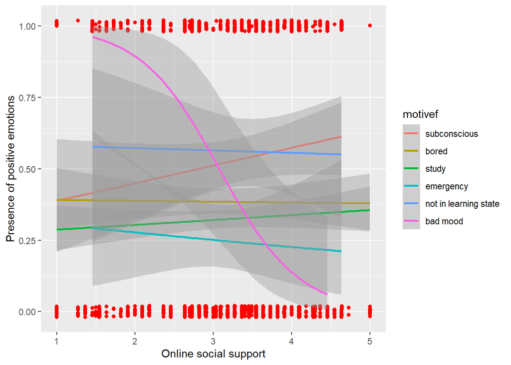

```
## Generalized linear mixed model fit by maximum likelihood (Adaptive
##   Gauss-Hermite Quadrature, nAGQ = 0) [glmerMod]
##  Family: binomial  ( logit )
## Formula: negbi ~ (1 | ID)
##    Data: set
## Control: glmerControl(optimizer = "bobyqa")
##
##      AIC      BIC   logLik deviance df.resid
##   1320.9   1331.6   -658.4   1316.9     1620
##
## Scaled residuals:
##     Min      1Q  Median      3Q     Max
## -2.4559 -0.4052 -0.2167 -0.1803  3.5229
##
## Random effects:
##  Groups Name        Variance Std.Dev.
##  ID     (Intercept) 3.254    1.804
## Number of obs: 1622, groups:  ID, 142
##
## Fixed effects:
##             Estimate Std. Error z value Pr(>|z|)
## (Intercept)  -1.8903     0.1787  -10.58   <2e-16 ***
## ---
## Signif. codes:  0 '***' 0.001 '**' 0.01 '*' 0.05 '.' 0.1 ' ' 1
```

```
## (Intercept)
##   0.1510229
```

Model1: add demographic covariates and level1 IV to the model:

```
## Generalized linear mixed model fit by maximum likelihood (Adaptive
##   Gauss-Hermite Quadrature, nAGQ = 0) [glmerMod]
##  Family: binomial  ( logit )
## Formula: negbi ~ CAge + gender + motivef + (1 | ID)
##    Data: set
## Control: glmerControl(optimizer = "bobyqa")
##
##      AIC      BIC   logLik deviance df.resid
##   1331.4   1379.9   -656.7   1313.4     1613
##
## Scaled residuals:
##     Min      1Q  Median      3Q     Max
## -2.2208 -0.4148 -0.2193 -0.1779  3.6029
##
## Random effects:
##  Groups Name        Variance Std.Dev.
##  ID     (Intercept) 3.2      1.789
## Number of obs: 1622, groups:  ID, 142
##
## Fixed effects:
##                              Estimate Std. Error z value Pr(>|z|)
## (Intercept)                  -1.63594    0.37705  -4.339 1.43e-05 ***
## CAge                          0.04299    0.21647   0.199    0.843
## genderMale                    0.09571    0.37229   0.257    0.797
## motivefbored                 -0.25067    0.30828  -0.813    0.416
## motivefstudy                 -0.39448    0.29928  -1.318    0.187
## motivefemergency             -0.78523    0.56258  -1.396    0.163
## motivefnot in learning state -0.21051    0.44754  -0.470    0.638
## motivefbad mood              -0.13511    0.59309  -0.228    0.820
## ---
## Signif. codes:  0 '***' 0.001 '**' 0.01 '*' 0.05 '.' 0.1 ' ' 1
##
## Correlation of Fixed Effects:
##             (Intr) CAge   gndrMl mtvfbr mtvfst mtvfmr mtvils
## CAge         0.106
## genderMale  -0.584 -0.181
## motivefbord -0.564  0.000 -0.041
## motivefstdy -0.610 -0.005 -0.037  0.735
## motvfmrgncy -0.316 -0.014 -0.009  0.389  0.414
## mtvfntinlrs -0.363 -0.029  0.001  0.430  0.468  0.284
## motivefbdmd -0.284 -0.025  0.000  0.358  0.372  0.205  0.226
```

```
##                  (Intercept)                         CAge
##                    0.1947696                    1.0439295
##                   genderMale                 motivefbored
##                    1.1004381                    0.7782780
##                 motivefstudy             motivefemergency
##                    0.6740338                    0.4560147
## motivefnot in learning state              motivefbad mood
##                    0.8101702                    0.8736187
```

Model2: add level2 IV to the model:

```
## Generalized linear mixed model fit by maximum likelihood (Adaptive
##   Gauss-Hermite Quadrature, nAGQ = 0) [glmerMod]
##  Family: binomial  ( logit )
## Formula: negbi ~ CAge + gender + motivef + Conline + (1 | ID)
##    Data: set
## Control: glmerControl(optimizer = "bobyqa")
##
##      AIC      BIC   logLik deviance df.resid
##   1325.5   1379.5   -652.8   1305.5     1612
##
## Scaled residuals:
##     Min      1Q  Median      3Q     Max
## -2.1903 -0.4247 -0.2238 -0.1579  3.7840
##
## Random effects:
##  Groups Name        Variance Std.Dev.
##  ID     (Intercept) 2.933    1.712
## Number of obs: 1622, groups:  ID, 142
##
## Fixed effects:
##                              Estimate Std. Error z value Pr(>|z|)
## (Intercept)                  -1.80129    0.37726  -4.775  1.8e-06 ***
## CAge                         -0.05365    0.21405  -0.251   0.8021
## genderMale                    0.32434    0.37140   0.873   0.3825
## motivefbored                 -0.21632    0.30738  -0.704   0.4816
## motivefstudy                 -0.36384    0.29791  -1.221   0.2220
## motivefemergency             -0.75162    0.56172  -1.338   0.1809
## motivefnot in learning state -0.20220    0.44623  -0.453   0.6505
## motivefbad mood              -0.09936    0.59199  -0.168   0.8667
## Conline                       0.51304    0.20699   2.479   0.0132 *
## ---
## Signif. codes:  0 '***' 0.001 '**' 0.01 '*' 0.05 '.' 0.1 ' ' 1
##
## Correlation of Fixed Effects:
##             (Intr) CAge   gndrMl mtvfbr mtvfst mtvfmr mtvils mtvfbm
## CAge         0.140
## genderMale  -0.596 -0.216
## motivefbord -0.572 -0.009 -0.028
## motivefstdy -0.616 -0.017 -0.026  0.735
## motvfmrgncy -0.319 -0.021 -0.002  0.389  0.414
## mtvfntinlrs -0.363 -0.033  0.003  0.430  0.468  0.282
## motivefbdmd -0.286 -0.032  0.006  0.356  0.369  0.203  0.224
## Conline     -0.205 -0.183  0.244  0.048  0.043  0.027  0.006  0.021
```

```
##                  (Intercept)                         CAge
##                    0.1650861                    0.9477600
##                   genderMale                 motivefbored
##                    1.3831158                    0.8054785
##                 motivefstudy             motivefemergency
##                    0.6949990                    0.4716037
## motivefnot in learning state              motivefbad mood
##                    0.8169349                    0.9054147
##                      Conline
##                    1.6703621
```

Model3: add cross-level interaction term to the model:

```
## Generalized linear mixed model fit by maximum likelihood (Adaptive
##   Gauss-Hermite Quadrature, nAGQ = 0) [glmerMod]
##  Family: binomial  ( logit )
## Formula: negbi ~ CAge + gender + motivef + Conline + motivef * Conline +
##     (1 | ID)
##    Data: set
## Control: glmerControl(optimizer = "bobyqa")
##
##      AIC      BIC   logLik deviance df.resid
##   1323.1   1403.9   -646.5   1293.1     1607
##
## Scaled residuals:
##     Min      1Q  Median      3Q     Max
## -2.1926 -0.4224 -0.2209 -0.1554  3.8314
##
## Random effects:
##  Groups Name        Variance Std.Dev.
##  ID     (Intercept) 3.005    1.734
## Number of obs: 1622, groups:  ID, 142
##
## Fixed effects:
##                                      Estimate Std. Error z value Pr(>|z|)
## (Intercept)                          -1.78595    0.40354  -4.426 9.61e-06 ***
## CAge                                 -0.04599    0.21613  -0.213   0.8315
## genderMale                            0.30189    0.37538   0.804   0.4213
## motivefbored                         -0.21450    0.34027  -0.630   0.5285
## motivefstudy                         -0.37260    0.33139  -1.124   0.2609
## motivefemergency                     -0.77983    0.58483  -1.333   0.1824
## motivefnot in learning state         -0.47027    0.53185  -0.884   0.3766
## motivefbad mood                      -0.40359    0.67602  -0.597   0.5505
## Conline                               0.46280    0.39949   1.158   0.2467
## motivefbored:Conline                  0.08673    0.41312   0.210   0.8337
## motivefstudy:Conline                  0.08280    0.40610   0.204   0.8384
## motivefemergency:Conline             -0.02157    0.73988  -0.029   0.9767
## motivefnot in learning state:Conline  0.80656    0.65494   1.231   0.2181
## motivefbad mood:Conline              -1.68742    0.70516  -2.393   0.0167 *
## ---
## Signif. codes:  0 '***' 0.001 '**' 0.01 '*' 0.05 '.' 0.1 ' ' 1
```

```
##
## Correlation matrix not shown by default, as p = 14 > 12.
## Use print(x, correlation=TRUE)  or
##     vcov(x)        if you need it
```

```
##                          (Intercept)                                 CAge
##                            0.1676379                            0.9550537
##                           genderMale                         motivefbored
##                            1.3524171                            0.8069477
##                         motivefstudy                     motivefemergency
##                            0.6889431                            0.4584827
##         motivefnot in learning state                      motivefbad mood
##                            0.6248314                            0.6679193
##                              Conline                 motivefbored:Conline
##                            1.5885198                            1.0906050
##                 motivefstudy:Conline             motivefemergency:Conline
##                            1.0863237                            0.9786563
## motivefnot in learning state:Conline              motivefbad mood:Conline
##                            2.2401877                            0.1849968
```

compare the 4 models to choose the best one:

```
## Data: set
## Models:
## m0: negbi ~ (1 | ID)
## m1: negbi ~ CAge + gender + motivef + (1 | ID)
##    npar    AIC    BIC  logLik deviance  Chisq Df Pr(>Chisq)
## m0    2 1320.9 1331.6 -658.43   1316.9
## m1    9 1331.4 1379.9 -656.70   1313.4 3.4661  7     0.8388
```

```
## Data: set
## Models:
## m1: negbi ~ CAge + gender + motivef + (1 | ID)
## m2: negbi ~ CAge + gender + motivef + Conline + (1 | ID)
##    npar    AIC    BIC  logLik deviance Chisq Df Pr(>Chisq)
## m1    9 1331.4 1379.9 -656.70   1313.4
## m2   10 1325.5 1379.5 -652.77   1305.5 7.845  1   0.005096 **
## ---
## Signif. codes:  0 '***' 0.001 '**' 0.01 '*' 0.05 '.' 0.1 ' ' 1
```

```
## Data: set
## Models:
## m2: negbi ~ CAge + gender + motivef + Conline + (1 | ID)
## m3: negbi ~ CAge + gender + motivef + Conline + motivef * Conline +
## m3:     (1 | ID)
##    npar    AIC    BIC  logLik deviance  Chisq Df Pr(>Chisq)
## m2   10 1325.5 1379.5 -652.77   1305.5
## m3   15 1323.1 1404.0 -646.54   1293.1 12.474  5    0.02884 *
## ---
## Signif. codes:  0 '***' 0.001 '**' 0.01 '*' 0.05 '.' 0.1 ' ' 1
```

Therefore, model3 is the best model to fit the data.

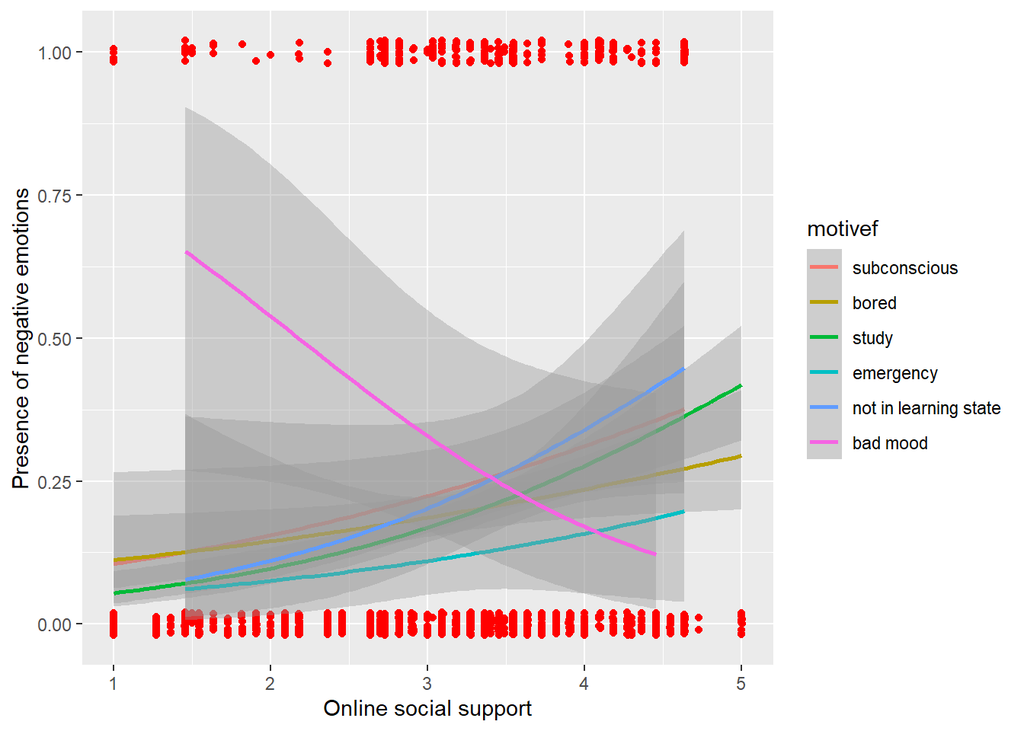